# Agile phd school

Marketa Beitlova

28 11 2019

## R Markdown

Name: Marketa Beitlova

University: Palacky univerity Olomouc

Country: Czech republic

**Title of the PhD thesis:**

Comparison of map reading by teachers and students

**Motivation:**

In my Ph.D. thesis, I am investigating map reading of students and their teachers using eye-tracking and I am comparing their reading strategies. Eye-tracking is a technology, that allows recording of the human gaze. It is widely used in many fields of research including GIS and cartography. Eye-tracking data is spatial-temporal data because eye movements are recorded over time in relation to space (screen or map).

The main aim of my Ph.D. thesis is to compare eye-movement trajectories of different groups of users - teachers and their students. I already have an experience in analyses and visualization of eye-tracking data using V-analytics tool (space-time cube and other). It can be used for eye-tracking data as well as for geospatial data.

## Visualization

I learned about possibilities how to visulize some kinds od data. How to do it easily and attractively. But for my reserch I need litte bit different king of visualization as scientific visualization. I need to anylyze the data not only diplay.

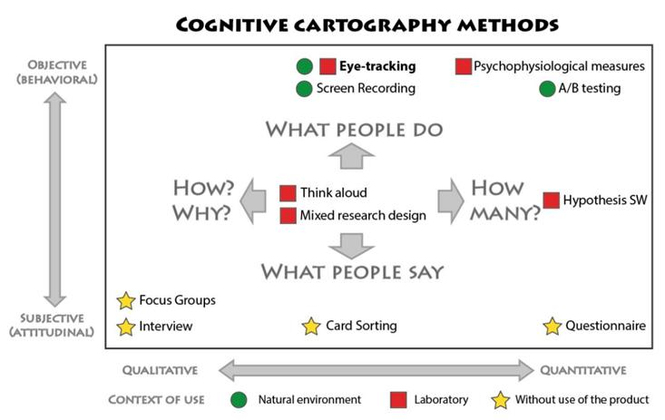

cognitive cartogrphy methods

## Reproducibility

Reproducibility topic was much more interestig for me. Reproducibility is very importatnt. I´ll ty to put somethig of this ideas into my reseach. Firstly, I will try to write my papers as reproducible as possible.

The practical part of this topic was very interesting I hope that we will use that for management of our eye-traking data.